# HW2

Dhanvin Lakshmisha

2025-01-28

Dhanvin Lakshmisha

dl37833

SDS 315

GitHub link - https://github.com/DhanvinL/SDS315-HW1

## Problem 1: Beauty, or not, in the classroom

### Part A - Creating a histogram

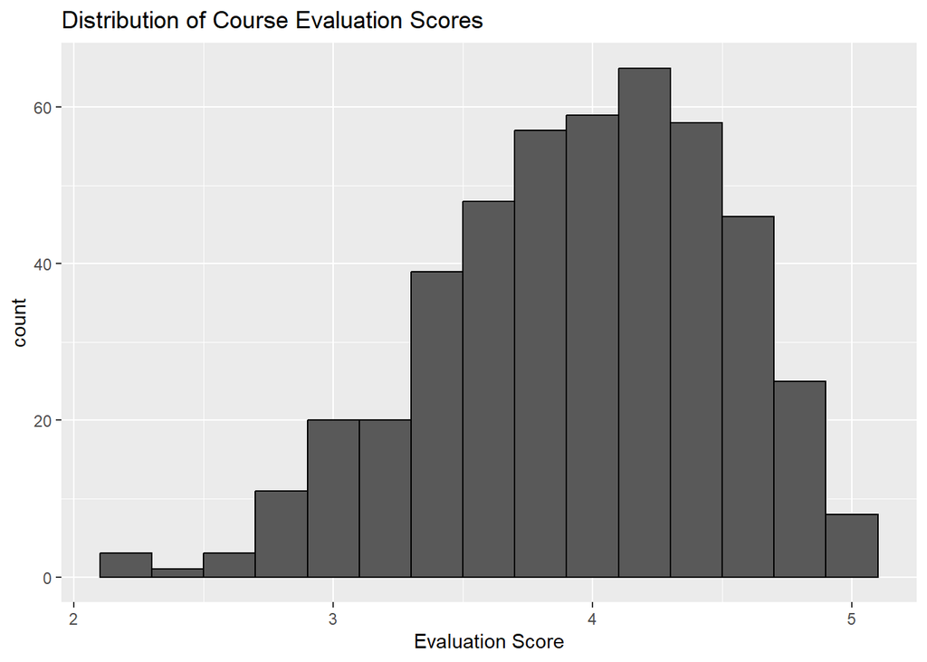

### Part B - Side by side boxplot

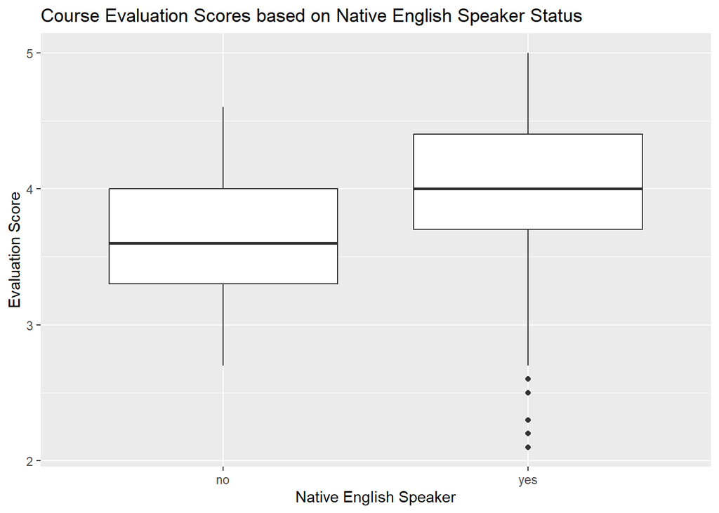

The boxplot shows a difference in medians, IQR, minimums, and maximums for evaluations based on whether the professor was a native English speaker. The summary statistics show that students rated native English higher than non-native English speakers. Also, the native English speaker distribution has a greater range than the non-native one, implying greater variability in scores for the native English speaker distribution. While native English speakers received better scores, they also had worse scores than non-native English speakers.

### Part C

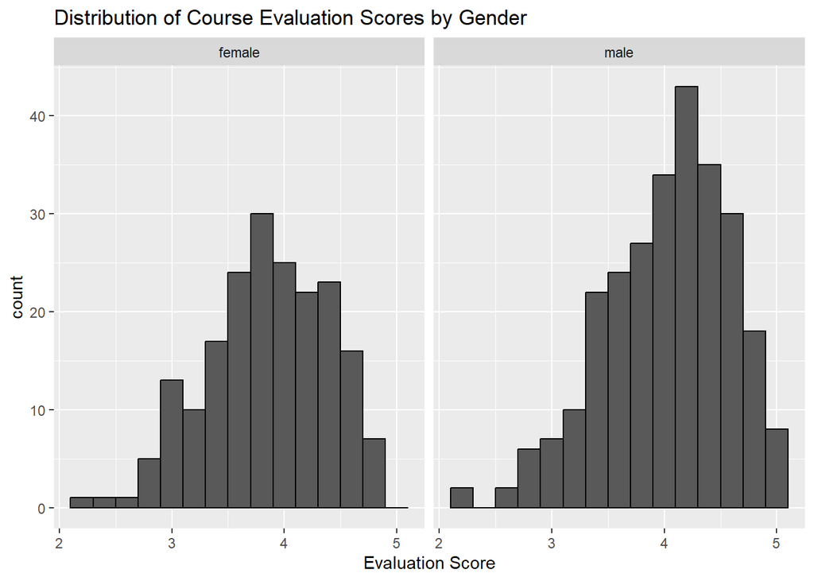

Both distributions are unimodal. Also, the male distribution appears to have a mean and median greater than the female distribution. The difference in mean and median between the two gender groups possibly indicates that male professors are generally rated higher than female professors. However, the male distribution may have more data points due to the higher counts for each score. Thus, additional data for female instructors to match that amount for male instructors may change the result and distribution.

### Part D

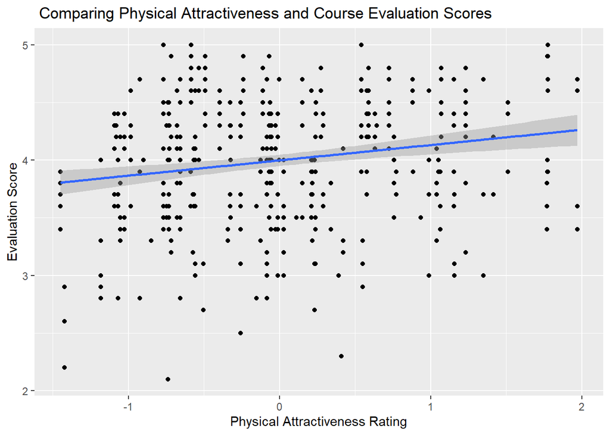

The data on the scatterplot is random and shows no obvious pattern or correlation. However, adding a regression line hints that professors with high attractiveness ratings may get higher evaluations scores than professors with low attractiveness ratings.

## Problem 2: bike sharing

### Plot A

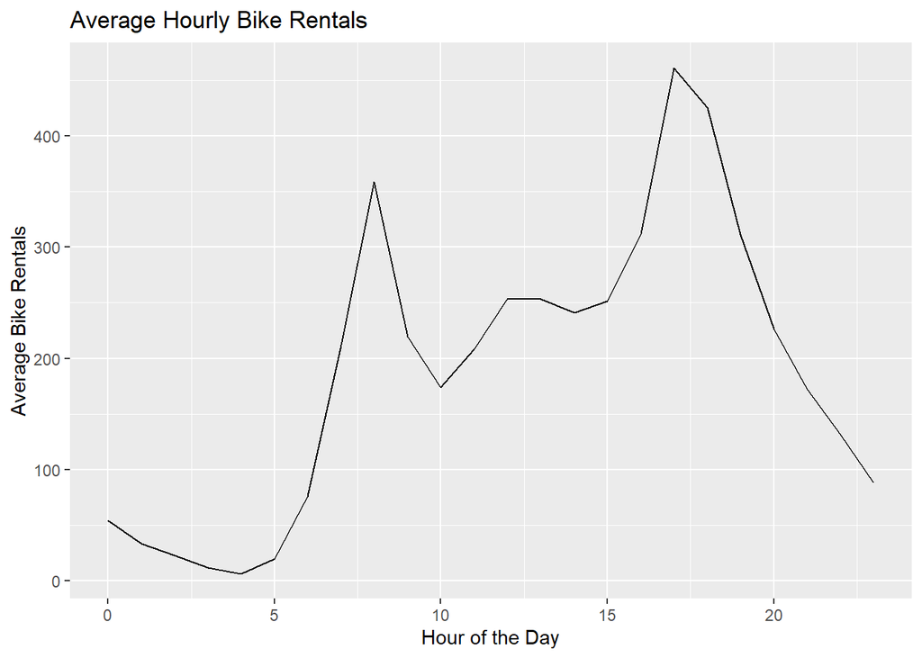

This plot displays a relationship between the hour of the day (in 24 hour time) and the average bike rentals during that hour of the day. There are lines are connected between each hour of the day. It is clear that there is a spike (or surge in average bike rentals) around 8 AM and around 6 PM. The highest relative average bike rentals are from 8 AM to 8 PM of a given day, as the lines remain high up toward the middle relative to the low exterior lines. This is reasonable as the middle of the day is when people are awake and use bikes to commute. 8 - 9 AM is usually the time people start to go to work so the spike of bike rentals toward this time makes sense. Also, the spike toward the end of the day conveys how people begin to partake in leisurely activities around that time, needing transportation to take them. Thus, the ridership patterns reflect the behavior and trends of average human activity throughout the day.

### Plot B

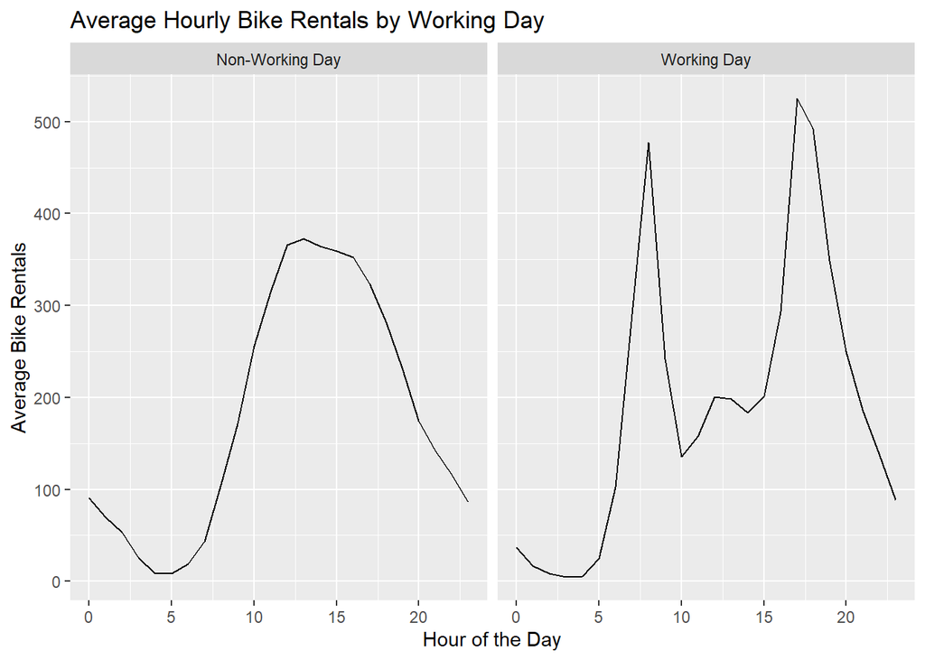

### Plot C

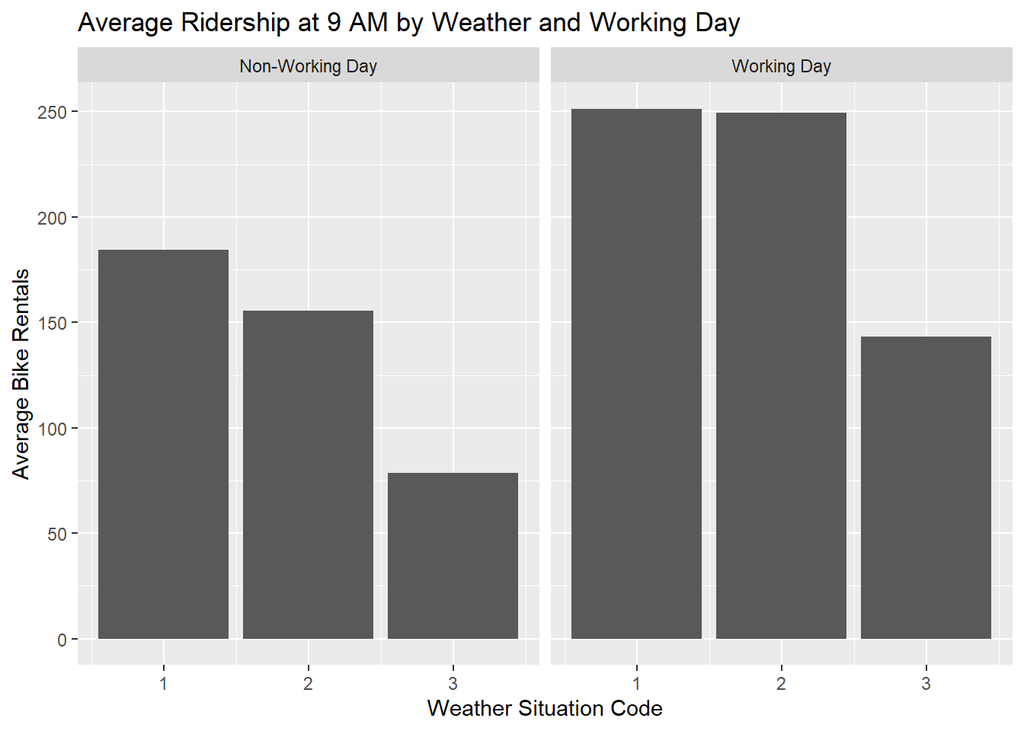

The plot shows average bike rentals based on weather situation codes(ex. 1 being clear/partly cloud, 2 being mist, 3 being light rain, and 4 being heavy rain) on working and non-working days. The averages for each weather code seem to be higher on working days than non-working days. This is most likely due to some work places not giving an option to stay home and work during days with disturbing weather. So, people have to commute using the bikes as transportation. On the other hand, non-working days have low average bike rentals during inclement weather due to not having the necessity to travel. Also, another trend in both types of working conditions is that as the weather becomes more severe (weather situation code increases) the less the rentals become. This is due to it becoming harder to travel in more disturbing weather. Thus, the weather condition, on both working and non-working days, has a clear impact on ridership patterns.

## Problem 3 - Capital Metro UT Ridership

### Question 1 - Line Graph

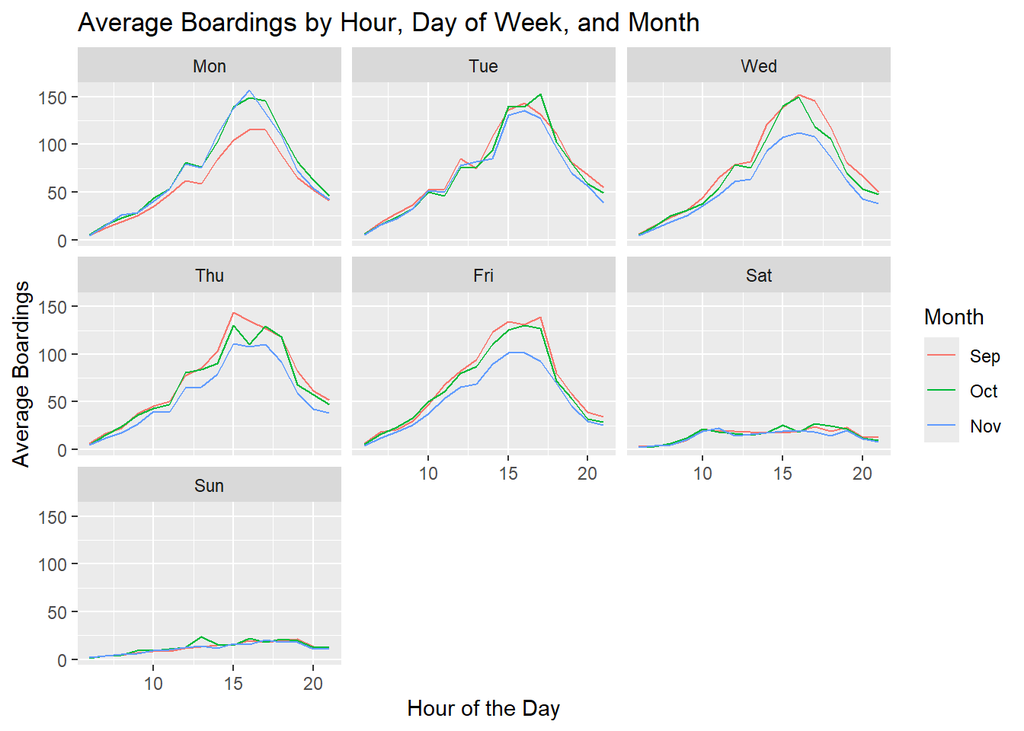

### Question 2 - Scatter Plot

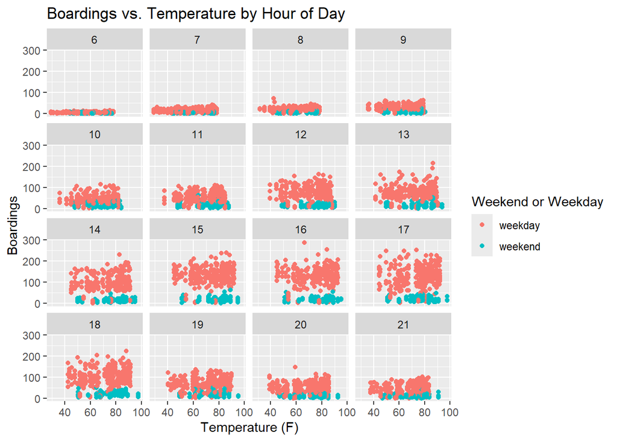

The graph shows a relationship between the temperature (in Fahrenheit) and the average boardings during that temperature for each hour of the day. Each scatterplot has two distinct colors, red indicating a weekday and blue indicating a weekend. When holding the hour of the day and weekend status constant, the temperature appears to have no noticeable effect on the number of UT students riding the bus. This is due to the lack of variability in each scatterplot across temperatures. For a clear effect to be shown because of temperature, the data points should show a pattern such as being clumped up in an area. However, the data points seem spread out in the x- axis the same way across all hours and days of the week. This suggests that temperature does not play a prominent role in determine boardings.

## Problem 4 - Wrangling the Billboard Top 100

### Part A

| performer | song | count |
| --- | --- | --- |
| Imagine Dragons | Radioactive | 87 |
| AWOLNATION | Sail | 79 |
| Jason Mraz | I'm Yours | 76 |
| The Weeknd | Blinding Lights | 76 |
| LeAnn Rimes | How Do I Live | 69 |
| LMFAO Featuring Lauren Bennett & GoonRock | Party Rock Anthem | 68 |
| OneRepublic | Counting Stars | 68 |
| Adele | Rolling In The Deep | 65 |
| Jewel | Foolish Games/You Were Meant For Me | 65 |
| Carrie Underwood | Before He Cheats | 64 |

The table shows the top 10 most popular songs measured by how many weeks they were on the Billboard top 100 list from the years 1958 to 2021. The list entails the artist, the song, and how many weeks the song was on the top 100 list (count).

### Part B

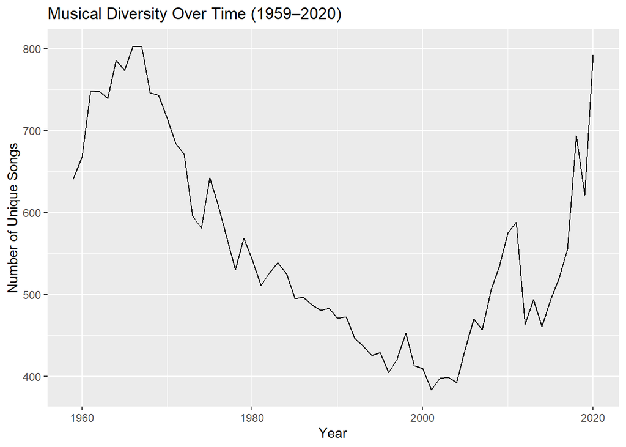

### Part C

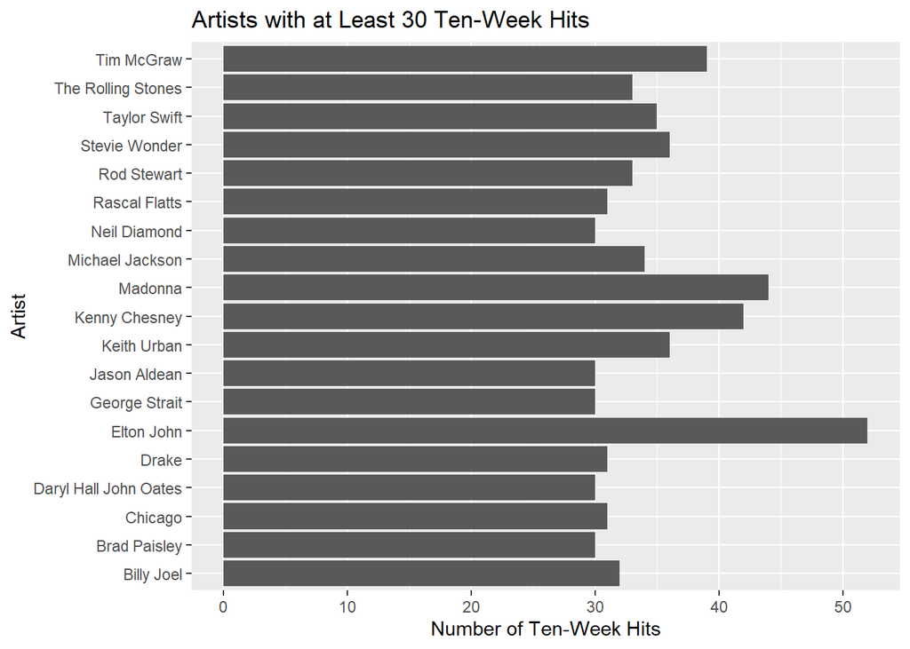

The graph shows the artists with the most ten-week hits (a song staying on the top 100 list for at least 10 weeks). Specifically, the graph shows artists with at least 30 songs that were ten week hits and the actual number of ten week hits they have. The artists names and the amount of ten-week hits they have are displayed. Exactly 19 artists have at least 30 ten-week hits in the time frame of the data set.